# Midterm Prep Key

## Quantile Function

### Practice 1

For the random variable $X \sim N(\mu_x = 5, \sigma_x=3)$

- Find $x$ such that $P(X < x) = 0.5$

```r
qnorm(0.5, 5, 3, lower.tail=TRUE)
```

```
## [1] 5
```

- Find $x$ such that $P(X < x) = 0.05$

```r
qnorm(0.05, 5, 3, lower.tail=TRUE)
```

```
## [1] 0.06543912
```

- Find $x$ such that $P(X \geq x) = 0.05$

```r
qnorm(0.05, 5, 3, lower.tail=FALSE)
```

```
## [1] 9.934561
```

### Practice 2

For the random variable $X \sim Poisson(\lambda=4)$

- Find $x$ such that $P(X \leq x) = 0.5$

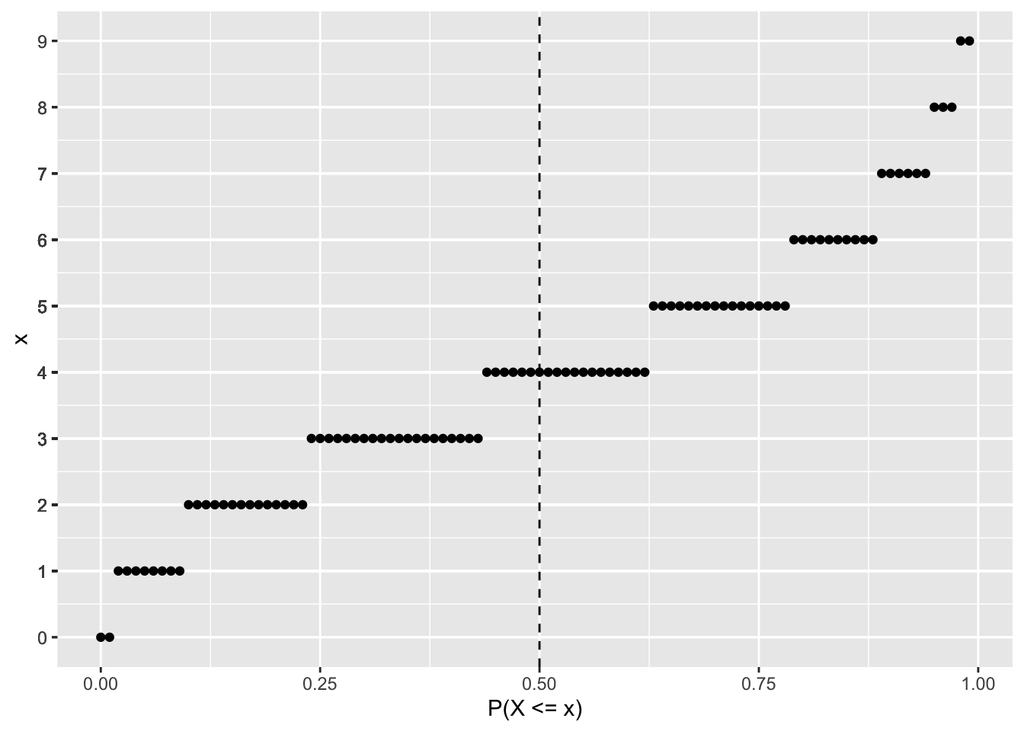

```r
p <- seq(0,0.99,0.01)
qf <- qpois(p, 4, lower.tail=TRUE)
d <- data.table(p, qf)
ggplot(d, aes(x=p, y=qf)) +
  geom_point() +
  scale_y_continuous(breaks=qf) +
  xlab('P(X <= x)') +
  ylab('x') +
  geom_vline(xintercept=0.5, linetype=2)
```

```r
qpois(0.5, 4, lower.tail=TRUE)
```

```
## [1] 4
```

- Find $x$ such that $P(X < x) = 0.05$

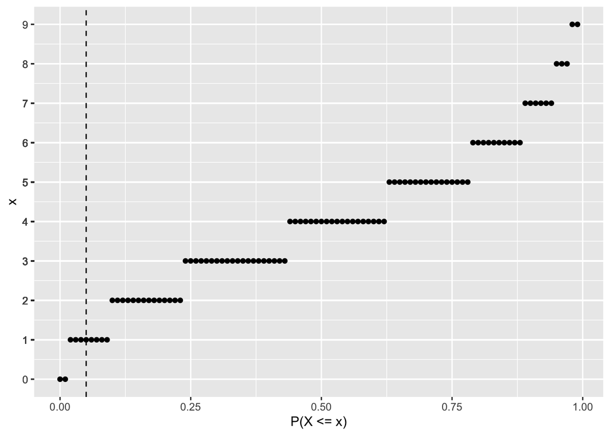

```r
p <- seq(0,0.99,0.01)
qf <- qpois(p, 4, lower.tail=TRUE)
d <- data.table(p, qf)
ggplot(d, aes(x=p, y=qf)) +
  geom_point() +
  scale_y_continuous(breaks=qf) +
  xlab('P(X <= x)') +
  ylab('x') +
  geom_vline(xintercept=0.05, linetype=2)
```

```r
qpois(0.05, 4, lower.tail=TRUE) - 1
```

```
## [1] 0
```

- Find $x$ such that $P(X > x) = 0.05$

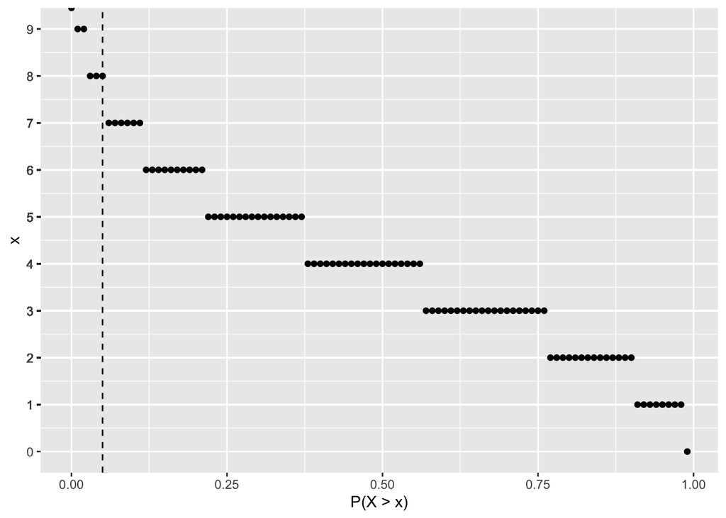

```r
p <- seq(0,0.99,0.01)
qf <- qpois(p, 4, lower.tail=FALSE)
d <- data.table(p, qf)
ggplot(d, aes(x=p, y=qf)) +
  geom_point() +
  scale_y_continuous(breaks=qf) +
  xlab('P(X > x)') +
  ylab('x') +
  geom_vline(xintercept=0.05, linetype=2)
```

```r
qpois(0.05, 4, lower.tail=FALSE)
```

```
## [1] 8
```

## NHST

### Practice 1

Consider an experiment in which participants first learn novel categories, and are subsequently asked to perform some other task. The question the researchers are interested in is how initial learning affects the subsequent task, and it is therefore critical that participants that didn’t learn anything be excluded from the final analysis. An exclusion criteria is set such that any participant that fails to reach at least $60\%$ accuracy by the end of training is excluded. Suppose that data is collected from 30 participants, and of these, 5 are excluded.

- Test the hypothesis that the true probability of meeting the exclusion criteria is greater than 01.

```r
## 1
## Let X = number excluded
## X ~ Binomial(n, p)

## H0: p = 0.1
## H1: p > 0.1

## 2
# alpha = 0.05

## 3
## p_hat = n_success / n_total
## p_hat ~ Binomial(n, p); x -> x/n_total
## "x/n_total" is to convert between count and proportion

## 4
n <- 30
p_hat_obs <- 5 / n

## 5
p_val <- pbinom(p_hat_obs*n-1, n, 0.1, lower.tail=FALSE)
p_hat_crit <- qbinom(0.05, n, 0.1, lower.tail=FALSE)/n

p_val
```

```
## [1] 0.1754949
```

```r
p_hat_crit
```

```
## [1] 0.2
```

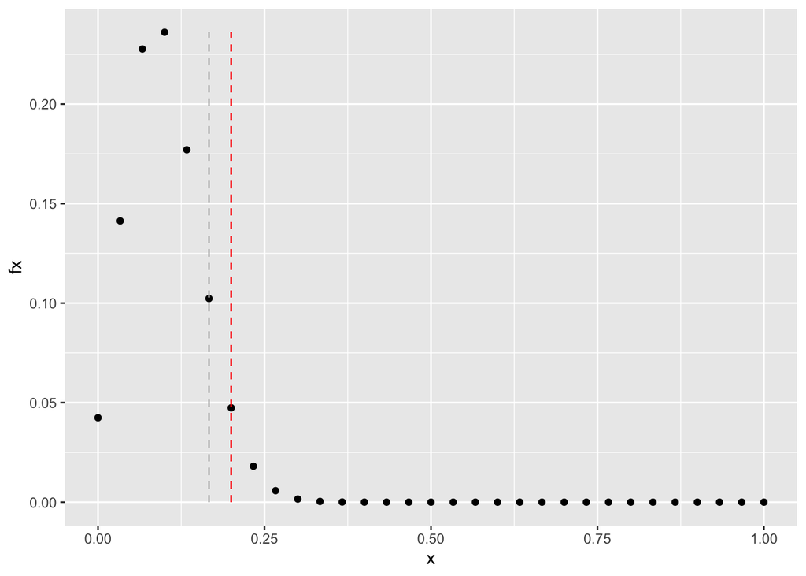

```r
x <- 0:n
fx <- dbinom(x, n, 0.1)
x <- x / n
d <- data.table(x, fx)
ggplot(d, aes(x, fx)) +
  geom_point() +
  geom_segment(aes(x=p_hat_obs,
                   xend=p_hat_obs,
                   y=0,
                   yend=max(fx)),
               linetype=2,
               colour='grey') +
  geom_segment(aes(x=p_hat_crit,
                   xend=p_hat_crit,
                   y=0,
                   yend=max(fx)),
               linetype=2,
               colour='red')
```

```r
if(p_val < 0.05) {
  print('reject H0')
} else {
  print('fail to reject H0')
}
```

```
## [1] "fail to reject H0"
```

```r
if(p_hat_obs > p_hat_crit) {
  print('reject H0')
} else {
  print('fail to reject H0')
}
```

```
## [1] "fail to reject H0"
```

```r
## NOTE: I haven't shown how to compute confidence interval
## estimates from Binomial random variables (or any discrete
## random variable for that matter). It follows the same
## principles in most ways as our approach for continuous
## random variables, but it turns out to be a bit more
## involved. Because of that, I will not ask you to compute
## CI estimates of a parameter from a discrete distribution.
```

- Is there a built in function you can use? If so, use it.

```r
binom.test(p_hat_obs*n, n=n, p=0.1, alternative='greater', conf.level=0.95)
```

```
##
##  Exact binomial test
##
## data:  p_hat_obs * n and n
## number of successes = 5, number of trials = 30, p-value = 0.1755
## alternative hypothesis: true probability of success is greater than 0.1
## 95 percent confidence interval:
##  0.06805557 1.00000000
## sample estimates:
## probability of success
##              0.1666667
```

- Report a point estimates for $\hat{p}$

```r
p_hat_obs
```

```
## [1] 0.1666667
```

- Report the critical value for $\alpha=0.05$

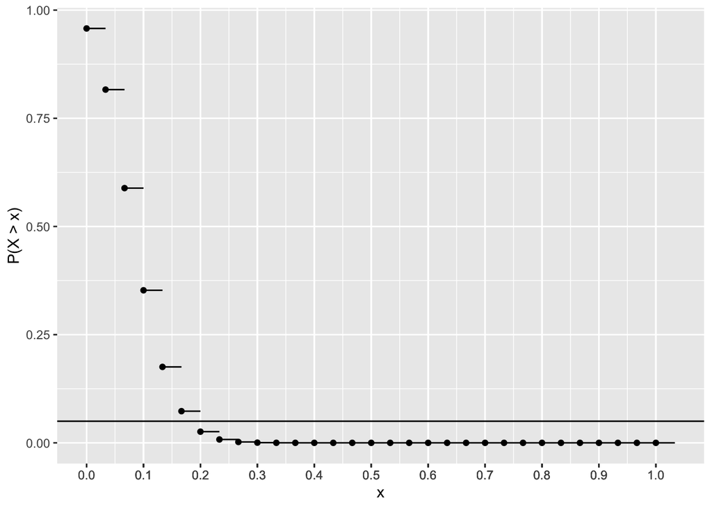

```r
x <- 0:n
fx <- pbinom(x, n, 0.1, lower.tail=FALSE)
x <- x/n
d <- data.table(x, fx)
ggplot(d, aes(x, fx)) +
  geom_point() +
  geom_hline(yintercept=0.05) +
  geom_segment(aes(x=x, xend=x+1/n, y=fx, yend=fx)) +
  scale_x_continuous(breaks=round(x, 1)) +
  ylab('P(X > x)') +
  xlab('x')
```

```r
p_hat_crit
```

```
## [1] 0.2
```

- Compute power against the alternative $H_1$ that $p$ is .3

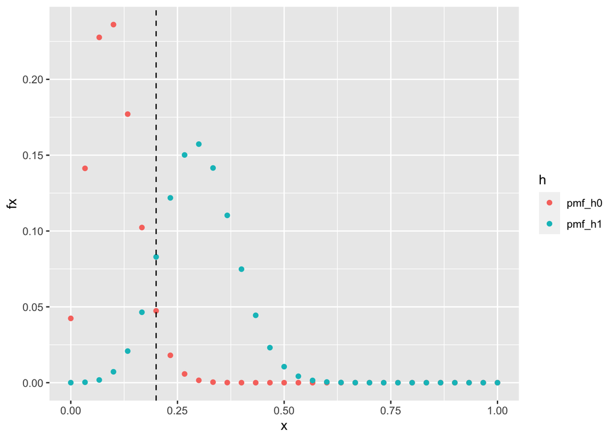

```r
x <- 0:30
pmf_h0 <- dbinom(x, n, 0.1)
pmf_h1 <- dbinom(x, n, 0.3)
x <- x/n
d <- data.table(x, pmf_h0, pmf_h1)
dd <- melt(d,
          id.vars='x',
          measure.vars=c('pmf_h0', 'pmf_h1'),
          variable.name='h',
          value.name='fx')
ggplot(dd) +
  geom_point(aes(x, fx, colour=h)) +
  geom_vline(xintercept=p_hat_crit, linetype=2)
```

```r
## power is the probability in the rejection region
type_I <- d[x > p_hat_crit, sum(pmf_h0)]
type_II <- d[x <= p_hat_crit, sum(pmf_h1)]
power <- d[x > p_hat_crit, sum(pmf_h1)]
```

### Practice 2

Consider an experiment in which participants study a list of words and are subsequently asked to recall as many of the studied words as possible. Suppose that data is collected from 10 participants and the percentage of words recalled by each participant is given by

$$\begin{equation}
x = ( 0.56, 0.56, 0.54, 0.64, 0.47, 0.67, 0.41, 0.57, 0.66, 0.62 )
\end{equation}$$

Let $X$ be the random variable that each participants performance is drawn from, and suppose we know $\sigma_x = 0.15$.

Is $\mu_x$ significantly greater than $0.6$?

```r
## 1
## H0: mux = .6
## H1: mux > .6

## 2
# alpha <- 0.05

## 3
## mu_x_hat = xbar
## x_bar ~ N(mu_x_bar, sig_x_bar)
## mu_x_bar = mu_x
## sig_x_bar = sig_x/sqrt(n)

n <- length(x)
sig_x <- 0.15
mu_x_bar <- 0.60
sig_x_bar <- sig_x/sqrt(n)

## 4
x_bar_obs <- mean(x)

## 5
p_val <- pnorm(x_bar_obs, mu_x_bar, sig_x_bar, lower.tail=FALSE)
x_bar_crit <- qnorm(0.05, mu_x_bar, sig_x_bar, lower.tail=FALSE)
```

- Is there a built-in function you can use? If so, use it.

```r
## Unfortunately, there is not.
```

- Report point and interval estimates for $\hat{\mu_x}$

```r
# point estimate
x_bar_obs
```

```
## [1] 0.5676709
```

```r
# interval estimate
ci_width <- qnorm(0.95, mu_x_bar, sig_x_bar) - qnorm(0.05, mu_x_bar, sig_x_bar)
ci_lower <- x_bar_obs - ci_width / 2
ci_upper <- x_bar_obs + ci_width / 2
```

- Report the critical value for $\alpha=0.05$

```r
x_bar_crit
```

```
## [1] 0.6780223
```

- Compute power against the alternative $H_1$ that $\mu_x$ is 0.62

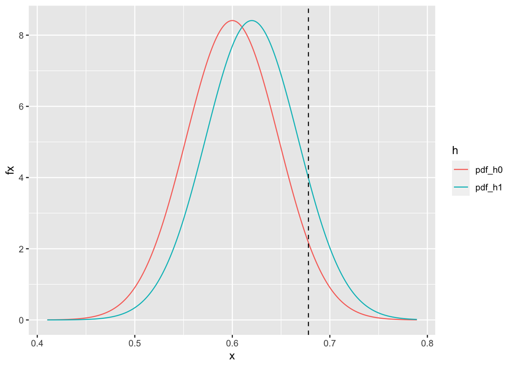

```r
x <- seq(mu_x_bar-sig_x_bar*4, mu_x_bar+sig_x_bar*4, 0.001)
pdf_h0 <- dnorm(x, 0.60, sig_x_bar)
pdf_h1 <- dnorm(x, 0.62, sig_x_bar)
d <- data.table(x, pdf_h0, pdf_h1)
dd <- melt(d,
          id.vars='x',
          measure.vars=c('pdf_h0', 'pdf_h1'),
          variable.name='h',
          value.name='fx')
ggplot(dd) +
  geom_line(aes(x, fx, colour=h)) +
  geom_vline(xintercept=x_bar_crit, linetype=2)
```

```r
typeI <- pnorm(x_bar_crit, 0.60, sig_x_bar, lower.tail=FALSE)
typeII <- pnorm(x_bar_crit, 0.62, sig_x_bar, lower.tail=TRUE)
power <- pnorm(x_bar_crit, 0.62, sig_x_bar, lower.tail=FALSE)
```

### Practice 3

Consider an experiment in which participants attempt to toss a ping pong ball as accurately as possible to a target. Suppose that data is collected from 15 participants and that the mean reach error per participant is given by

$$\begin{equation}
x = ( 12.06, -0.86, 7.55, 16.29, -10.36, -19.27, 0.7, -3.54, -8.14, -6.5, -9.74, 10.9, 17.28, 14.88, -6.44 )
\end{equation}$$

Let $X$ be the random variable that each participants performance is drawn from.

Is $\mu_x$ significantly different from $0$?

```r
## 1
## H0: mux = 0
## H1: mux != 0

## 2
# alpha <- 0.05

## 3
## mu_x_hat = x_bar ~ N(mu_x_bar, sig_x_bar)
## mu_x_bar = mu_x
## sig_x_bar = sig_x / sqrt(n)
## Don't know sig_x so we need to estimate it
## This means we need to transform everything for a t-test
## t_x_bar = (x_bar - mu_x_bar) / sig_x_bar
## t_x_bar ~ t(n-1)

n <- length(x)
df <- n - 1
mu_x_bar <- 0

sig_x <- sd(x)
sig_x_bar <- sig_x/sqrt(n)

## 4
x_bar_obs <- mean(x)
t_obs <- (x_bar_obs - mu_x_bar) / sig_x_bar

## 5
p_val_lower <- pt(-abs(t_obs), n-1, lower.tail = TRUE)
p_val_upper <- pt(abs(t_obs), n-1, lower.tail = FALSE)
p_val <- p_val_lower + p_val_upper

t_crit_lower <- qt(0.025, n-1)
t_crit_upper <- qt(0.975, n-1)
```

- Is there a built in function you can use? If so, use it.

```r
t.test(x, mu=0, alternative='two.sided')
```

```
##
##  One Sample t-test
##
## data:  x
## t = 0.33459, df = 14, p-value = 0.7429
## alternative hypothesis: true mean is not equal to 0
## 95 percent confidence interval:
##  -5.342954  7.318086
## sample estimates:
## mean of x
##  0.987566
```

- Report point and interval estimates for $\hat{\mu_x}$

```r
# The insight you have to have here is that to convert
# between t which has mean 0 and (approximately) sd 1, you
# have to scale the interval you get from the t by sig_x_bar.
ci_width <- ( t_crit_upper - t_crit_lower) * sig_x_bar
ci_lower <- x_bar_obs - ci_width / 2
ci_upper <- x_bar_obs + ci_width / 2

# print out stuff to compare with t.test()
p_val
```

```
## [1] 0.7428955
```

```r
ci_lower
```

```
## [1] -5.342954
```

```r
ci_upper
```

```
## [1] 7.318086
```

- Report the critical values for $\alpha=0.05$

```r
t_crit_lower
```

```
## [1] -2.144787
```

```r
t_crit_upper
```

```
## [1] 2.144787
```

- Compute power against the alternative $H_1$ that $\mu_x$ is 2.

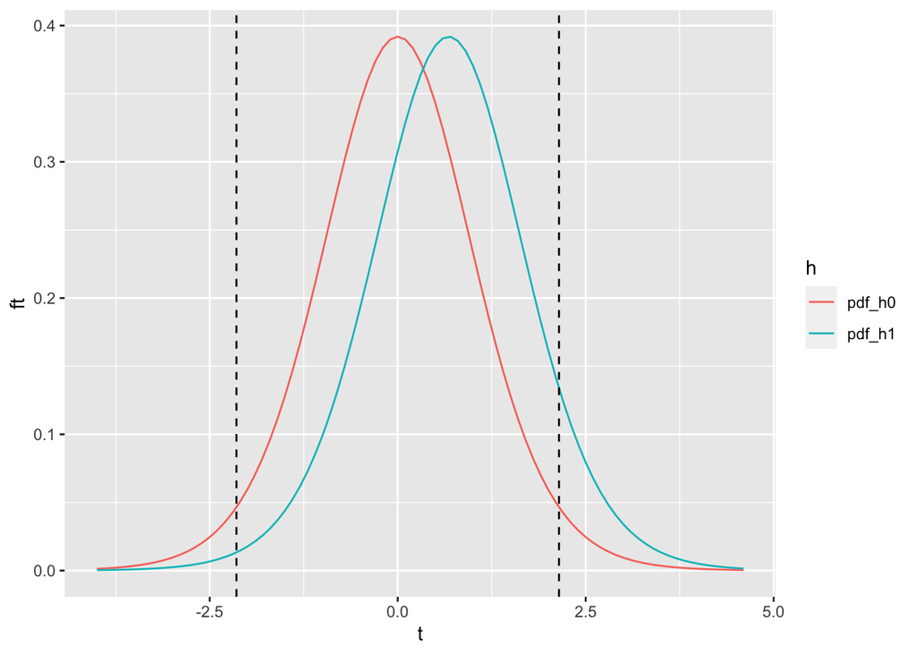

```r
# In x_bar units the mean of the null and the alternative
# are 2 units apart. However, since we have to estimate the
# population standard deviation from the data, we need to
# work with t-distributions.
# mu_h0 = 0 --> t
# mu_h1 = 2 --> t + 2/sig_x_bar
lower_t <- -4
upper_t <- 2/sig_x_bar + 4
t <- seq(lower_t, upper_t, 0.1)
pdf_h0 <- dt(t, n-1)
pdf_h1 <- dt(t-2/sig_x_bar, n-1)
d <- data.table(t, pdf_h0, pdf_h1)
dd <- melt(d,
          id.vars='t',
          measure.vars=c('pdf_h0', 'pdf_h1'),
          variable.name='h',
          value.name='ft')
ggplot(dd) +
  geom_line(aes(t, ft, colour=h)) +
  geom_vline(xintercept=t_crit_lower, linetype=2) +
  geom_vline(xintercept=t_crit_upper, linetype=2)
```

```r
# contribution from upper tail
typeI <- pt(t_crit_upper, n-1, lower.tail=FALSE)
typeII <- pt(t_crit_upper-2/sig_x_bar, n-1, lower.tail=TRUE)
power <- pt(t_crit_upper-2/sig_x_bar, n-1, lower.tail=FALSE)

# contribution from lower tail
# TODO:...
```

[output not shown]

## Data Wrangling

### Practice 1

- Convert the following `data.table` to long format
- The `data.table` can be found here: https://crossley.github.io/cogs2020/data/maze/d_wide.csv

```
##    maze_time_rat_1 maze_time_rat_2 maze_time_rat_3 maze_time_rat_4
## 1:       223.83041       16.795670       183.20471        20.46609
## 2:        72.06537      -16.657055        77.26713        94.51225
## 3:       275.79031       -6.559058       126.61374       125.01413
## 4:       156.07461      -56.378205        62.32973       161.82433
## 5:        54.72160      215.653700       344.13646        82.73765
##    maze_time_rat_5 run
## 1:     -122.390027   1
## 2:      -26.361438   2
## 3:      135.872890   3
## 4:       98.895452   4
## 5:        5.935084   5
```

```r
d <- fread('https://crossley.github.io/cogs2020/data/maze/d_wide.csv')
melt(d, id.vars=c('run'))
```

```
##     run        variable       value
##  1:   1 maze_time_rat_1  223.830410
##  2:   2 maze_time_rat_1   72.065372
##  3:   3 maze_time_rat_1  275.790309
##  4:   4 maze_time_rat_1  156.074609
##  5:   5 maze_time_rat_1   54.721603
##  6:   1 maze_time_rat_2   16.795670
##  7:   2 maze_time_rat_2  -16.657055
##  8:   3 maze_time_rat_2   -6.559058
##  9:   4 maze_time_rat_2  -56.378205
## 10:   5 maze_time_rat_2  215.653700
## 11:   1 maze_time_rat_3  183.204713
## 12:   2 maze_time_rat_3   77.267131
## 13:   3 maze_time_rat_3  126.613736
## 14:   4 maze_time_rat_3   62.329728
## 15:   5 maze_time_rat_3  344.136463
## 16:   1 maze_time_rat_4   20.466088
## 17:   2 maze_time_rat_4   94.512253
## 18:   3 maze_time_rat_4  125.014132
## 19:   4 maze_time_rat_4  161.824329
## 20:   5 maze_time_rat_4   82.737650
## 21:   1 maze_time_rat_5 -122.390027
## 22:   2 maze_time_rat_5  -26.361438
## 23:   3 maze_time_rat_5  135.872890
## 24:   4 maze_time_rat_5   98.895452
## 25:   5 maze_time_rat_5    5.935084
##     run        variable       value
```

### Practice 2

- Convert the following `data.table` to wide format
- The `data.table` can be found here: https://crossley.github.io/cogs2020/data/maze/d_long.csv

```
##     run rat  maze_time
##  1:   1   1  88.417468
##  2:   1   2  18.503129
##  3:   1   3 124.226348
##  4:   1   4 -42.509839
##  5:   1   5 136.594112
##  6:   2   1 124.841265
##  7:   2   2 106.528818
##  8:   2   3 101.915639
##  9:   2   4 125.733838
## 10:   2   5  35.098992
## 11:   3   1  88.083124
## 12:   3   2 166.413570
## 13:   3   3 210.096910
## 14:   3   4 114.377148
## 15:   3   5  88.224640
## 16:   4   1   8.793163
## 17:   4   2 -43.758624
## 18:   4   3  20.291047
## 19:   4   4 225.408311
## 20:   4   5 177.214219
## 21:   5   1  78.048437
## 22:   5   2  57.518972
## 23:   5   3  58.101990
## 24:   5   4 199.698686
## 25:   5   5  72.422197
##     run rat  maze_time
```

```r
d <- fread('https://crossley.github.io/cogs2020/data/maze/d_long.csv')
dcast(d, run ~ rat, value.var='maze_time')
```

```
##    run          1         2         3         4         5
## 1:   1  88.417468  18.50313 124.22635 -42.50984 136.59411
## 2:   2 124.841265 106.52882 101.91564 125.73384  35.09899
## 3:   3  88.083124 166.41357 210.09691 114.37715  88.22464
## 4:   4   8.793163 -43.75862  20.29105 225.40831 177.21422
## 5:   5  78.048437  57.51897  58.10199 199.69869  72.42220
```

### Practice 3

Consider an experiment in which a set of rats run through a set of mazes some number of times each. The researchers running this experiment are interested in how quickly rats can run these mazes, and so they record the time in seconds each rat takes to complete each run of each maze. The data for the experiment they performed can be found here:

https://crossley.github.io/cogs2020/data/maze/maze.csv

- Recreate the following visualisation of their results. Note that error bars represent standard error of the mean (SEM).

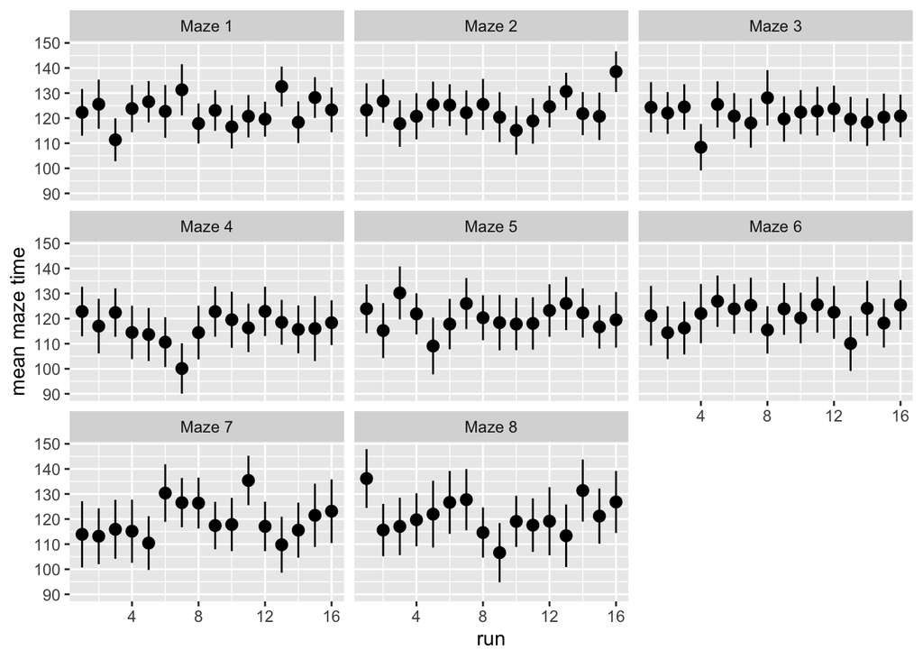

```r
d <- fread("https://crossley.github.io/cogs2020/data/maze/maze.csv")
dd <- d[, .(mean(time), sd(time)/sqrt(length(unique(rat)))), .(maze, run)]

ggplot(dd, aes(run, V1)) +
  geom_pointrange(aes(ymin=V1-V2, ymax=V1+V2)) +
  xlab('run') +
  ylab('mean maze time') +
  facet_wrap(~factor(maze, labels=c('Maze ')))
```

- Recreate the following visualisation of their results. Note that error bars represent standard error of the mean (SEM). Also note that to get SEM here, first compute the mean `time` per `maze` for each `rat`. Then, compute the mean and standard error from these values.

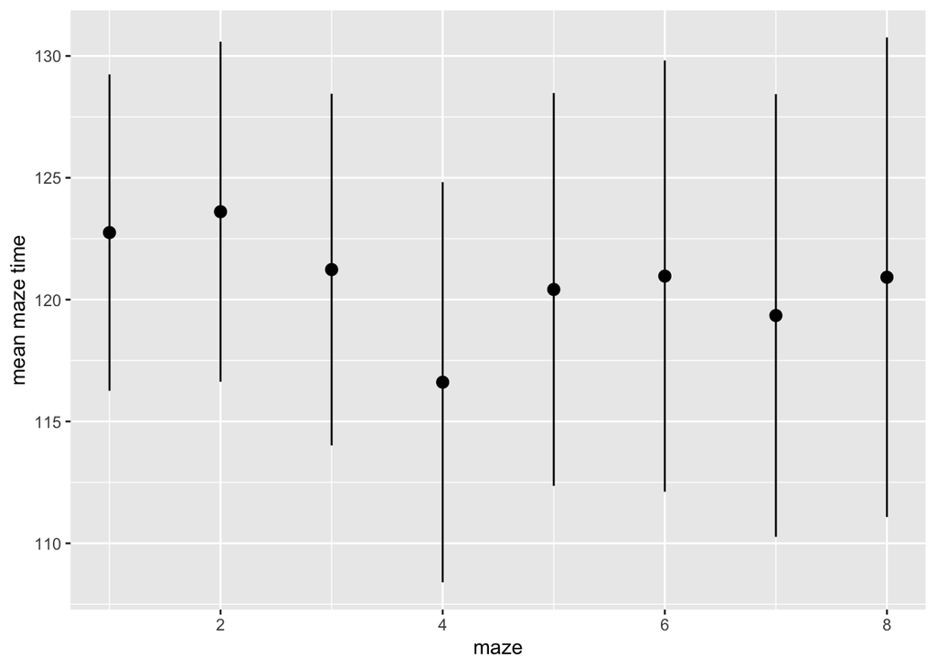

```r
dd <- d[, mean(time), .(rat, maze)]
ddd <- dd[, .(mean(V1), sd(V1)/sqrt(length(unique(rat)))), .(maze)]
ggplot(ddd, aes(maze, V1)) +
  geom_pointrange(aes(ymin=V1-V2, ymax=V1+V2)) +
  xlab('maze') +
  ylab('mean maze time')
```